# Risk Factor Analysis

## Outcome Variable

**Outcome Variable:** pers_wast

## Predictor Variables

**Intervention Variable:** cleanck

**Adjustment Set:**

unadjusted

## Stratifying Variables

The analysis was stratified on these variable(s):

- agecat
- studyid
- country

## Data Summary

| agecat | studyid | country | cleanck | pers_wast | n_cell | n |
| --- | --- | --- | --- | --- | --- | --- |
| 0-24 months | ki0047075b-MAL-ED | PERU | 0 | 0 | 0 | 1 |
| 0-24 months | ki0047075b-MAL-ED | PERU | 0 | 1 | 0 | 1 |
| 0-24 months | ki0047075b-MAL-ED | PERU | 1 | 0 | 1 | 1 |
| 0-24 months | ki0047075b-MAL-ED | PERU | 1 | 1 | 0 | 1 |
| 0-24 months | ki0047075b-MAL-ED | SOUTH AFRICA | 0 | 0 | 1 | 2 |
| 0-24 months | ki0047075b-MAL-ED | SOUTH AFRICA | 0 | 1 | 0 | 2 |
| 0-24 months | ki0047075b-MAL-ED | SOUTH AFRICA | 1 | 0 | 1 | 2 |
| 0-24 months | ki0047075b-MAL-ED | SOUTH AFRICA | 1 | 1 | 0 | 2 |
| 0-24 months | ki1000108-CMC-V-BCS-2002 | INDIA | 0 | 0 | 193 | 373 |
| 0-24 months | ki1000108-CMC-V-BCS-2002 | INDIA | 0 | 1 | 17 | 373 |
| 0-24 months | ki1000108-CMC-V-BCS-2002 | INDIA | 1 | 0 | 157 | 373 |
| 0-24 months | ki1000108-CMC-V-BCS-2002 | INDIA | 1 | 1 | 6 | 373 |
| 0-24 months | ki1000108-IRC | INDIA | 0 | 0 | 148 | 400 |
| 0-24 months | ki1000108-IRC | INDIA | 0 | 1 | 21 | 400 |
| 0-24 months | ki1000108-IRC | INDIA | 1 | 0 | 204 | 400 |
| 0-24 months | ki1000108-IRC | INDIA | 1 | 1 | 27 | 400 |
| 0-24 months | ki1017093b-PROVIDE | BANGLADESH | 0 | 0 | 105 | 640 |
| 0-24 months | ki1017093b-PROVIDE | BANGLADESH | 0 | 1 | 6 | 640 |
| 0-24 months | ki1017093b-PROVIDE | BANGLADESH | 1 | 0 | 520 | 640 |
| 0-24 months | ki1017093b-PROVIDE | BANGLADESH | 1 | 1 | 9 | 640 |
| 0-24 months | ki1017093c-NIH-Crypto | BANGLADESH | 0 | 0 | 210 | 559 |
| 0-24 months | ki1017093c-NIH-Crypto | BANGLADESH | 0 | 1 | 6 | 559 |
| 0-24 months | ki1017093c-NIH-Crypto | BANGLADESH | 1 | 0 | 335 | 559 |
| 0-24 months | ki1017093c-NIH-Crypto | BANGLADESH | 1 | 1 | 8 | 559 |
| 0-24 months | ki1113344-GMS-Nepal | NEPAL | 0 | 0 | 894 | 1060 |
| 0-24 months | ki1113344-GMS-Nepal | NEPAL | 0 | 1 | 150 | 1060 |
| 0-24 months | ki1113344-GMS-Nepal | NEPAL | 1 | 0 | 14 | 1060 |
| 0-24 months | ki1113344-GMS-Nepal | NEPAL | 1 | 1 | 2 | 1060 |
| 0-6 months | ki0047075b-MAL-ED | PERU | 0 | 0 | 0 | 1 |
| 0-6 months | ki0047075b-MAL-ED | PERU | 0 | 1 | 0 | 1 |
| 0-6 months | ki0047075b-MAL-ED | PERU | 1 | 0 | 1 | 1 |
| 0-6 months | ki0047075b-MAL-ED | PERU | 1 | 1 | 0 | 1 |
| 0-6 months | ki0047075b-MAL-ED | SOUTH AFRICA | 0 | 0 | 1 | 2 |
| 0-6 months | ki0047075b-MAL-ED | SOUTH AFRICA | 0 | 1 | 0 | 2 |
| 0-6 months | ki0047075b-MAL-ED | SOUTH AFRICA | 1 | 0 | 1 | 2 |
| 0-6 months | ki0047075b-MAL-ED | SOUTH AFRICA | 1 | 1 | 0 | 2 |
| 0-6 months | ki1000108-CMC-V-BCS-2002 | INDIA | 0 | 0 | 165 | 358 |
| 0-6 months | ki1000108-CMC-V-BCS-2002 | INDIA | 0 | 1 | 35 | 358 |
| 0-6 months | ki1000108-CMC-V-BCS-2002 | INDIA | 1 | 0 | 143 | 358 |
| 0-6 months | ki1000108-CMC-V-BCS-2002 | INDIA | 1 | 1 | 15 | 358 |
| 0-6 months | ki1000108-IRC | INDIA | 0 | 0 | 141 | 392 |
| 0-6 months | ki1000108-IRC | INDIA | 0 | 1 | 24 | 392 |
| 0-6 months | ki1000108-IRC | INDIA | 1 | 0 | 189 | 392 |
| 0-6 months | ki1000108-IRC | INDIA | 1 | 1 | 38 | 392 |
| 0-6 months | ki1017093b-PROVIDE | BANGLADESH | 0 | 0 | 107 | 637 |
| 0-6 months | ki1017093b-PROVIDE | BANGLADESH | 0 | 1 | 4 | 637 |
| 0-6 months | ki1017093b-PROVIDE | BANGLADESH | 1 | 0 | 516 | 637 |
| 0-6 months | ki1017093b-PROVIDE | BANGLADESH | 1 | 1 | 10 | 637 |
| 0-6 months | ki1113344-GMS-Nepal | NEPAL | 0 | 0 | 840 | 972 |
| 0-6 months | ki1113344-GMS-Nepal | NEPAL | 0 | 1 | 118 | 972 |
| 0-6 months | ki1113344-GMS-Nepal | NEPAL | 1 | 0 | 10 | 972 |
| 0-6 months | ki1113344-GMS-Nepal | NEPAL | 1 | 1 | 4 | 972 |
| 6-24 months | ki0047075b-MAL-ED | SOUTH AFRICA | 0 | 0 | 0 | 1 |
| 6-24 months | ki0047075b-MAL-ED | SOUTH AFRICA | 0 | 1 | 0 | 1 |
| 6-24 months | ki0047075b-MAL-ED | SOUTH AFRICA | 1 | 0 | 1 | 1 |
| 6-24 months | ki0047075b-MAL-ED | SOUTH AFRICA | 1 | 1 | 0 | 1 |
| 6-24 months | ki1000108-CMC-V-BCS-2002 | INDIA | 0 | 0 | 189 | 373 |
| 6-24 months | ki1000108-CMC-V-BCS-2002 | INDIA | 0 | 1 | 21 | 373 |
| 6-24 months | ki1000108-CMC-V-BCS-2002 | INDIA | 1 | 0 | 156 | 373 |
| 6-24 months | ki1000108-CMC-V-BCS-2002 | INDIA | 1 | 1 | 7 | 373 |
| 6-24 months | ki1000108-IRC | INDIA | 0 | 0 | 146 | 400 |
| 6-24 months | ki1000108-IRC | INDIA | 0 | 1 | 23 | 400 |
| 6-24 months | ki1000108-IRC | INDIA | 1 | 0 | 206 | 400 |
| 6-24 months | ki1000108-IRC | INDIA | 1 | 1 | 25 | 400 |
| 6-24 months | ki1017093b-PROVIDE | BANGLADESH | 0 | 0 | 90 | 601 |
| 6-24 months | ki1017093b-PROVIDE | BANGLADESH | 0 | 1 | 13 | 601 |
| 6-24 months | ki1017093b-PROVIDE | BANGLADESH | 1 | 0 | 473 | 601 |
| 6-24 months | ki1017093b-PROVIDE | BANGLADESH | 1 | 1 | 25 | 601 |
| 6-24 months | ki1017093c-NIH-Crypto | BANGLADESH | 0 | 0 | 202 | 533 |
| 6-24 months | ki1017093c-NIH-Crypto | BANGLADESH | 0 | 1 | 11 | 533 |
| 6-24 months | ki1017093c-NIH-Crypto | BANGLADESH | 1 | 0 | 306 | 533 |
| 6-24 months | ki1017093c-NIH-Crypto | BANGLADESH | 1 | 1 | 14 | 533 |
| 6-24 months | ki1113344-GMS-Nepal | NEPAL | 0 | 0 | 826 | 1034 |
| 6-24 months | ki1113344-GMS-Nepal | NEPAL | 0 | 1 | 192 | 1034 |
| 6-24 months | ki1113344-GMS-Nepal | NEPAL | 1 | 0 | 14 | 1034 |
| 6-24 months | ki1113344-GMS-Nepal | NEPAL | 1 | 1 | 2 | 1034 |

The following strata were considered:

- agecat: 0-24 months, studyid: ki0047075b-MAL-ED, country: PERU
- agecat: 0-24 months, studyid: ki0047075b-MAL-ED, country: SOUTH AFRICA
- agecat: 0-24 months, studyid: ki1000108-CMC-V-BCS-2002, country: INDIA
- agecat: 0-24 months, studyid: ki1000108-IRC, country: INDIA
- agecat: 0-24 months, studyid: ki1017093b-PROVIDE, country: BANGLADESH
- agecat: 0-24 months, studyid: ki1017093c-NIH-Crypto, country: BANGLADESH
- agecat: 0-24 months, studyid: ki1113344-GMS-Nepal, country: NEPAL
- agecat: 0-6 months, studyid: ki0047075b-MAL-ED, country: PERU
- agecat: 0-6 months, studyid: ki0047075b-MAL-ED, country: SOUTH AFRICA
- agecat: 0-6 months, studyid: ki1000108-CMC-V-BCS-2002, country: INDIA
- agecat: 0-6 months, studyid: ki1000108-IRC, country: INDIA
- agecat: 0-6 months, studyid: ki1017093b-PROVIDE, country: BANGLADESH
- agecat: 0-6 months, studyid: ki1113344-GMS-Nepal, country: NEPAL
- agecat: 6-24 months, studyid: ki0047075b-MAL-ED, country: SOUTH AFRICA
- agecat: 6-24 months, studyid: ki1000108-CMC-V-BCS-2002, country: INDIA
- agecat: 6-24 months, studyid: ki1000108-IRC, country: INDIA
- agecat: 6-24 months, studyid: ki1017093b-PROVIDE, country: BANGLADESH
- agecat: 6-24 months, studyid: ki1017093c-NIH-Crypto, country: BANGLADESH
- agecat: 6-24 months, studyid: ki1113344-GMS-Nepal, country: NEPAL

### Dropped Strata

Some strata were dropped due to rare outcomes:

- agecat: 0-24 months, studyid: ki0047075b-MAL-ED, country: PERU
- agecat: 0-24 months, studyid: ki0047075b-MAL-ED, country: SOUTH AFRICA
- agecat: 0-24 months, studyid: ki1113344-GMS-Nepal, country: NEPAL
- agecat: 0-6 months, studyid: ki0047075b-MAL-ED, country: PERU
- agecat: 0-6 months, studyid: ki0047075b-MAL-ED, country: SOUTH AFRICA
- agecat: 0-6 months, studyid: ki1017093b-PROVIDE, country: BANGLADESH
- agecat: 0-6 months, studyid: ki1113344-GMS-Nepal, country: NEPAL
- agecat: 6-24 months, studyid: ki0047075b-MAL-ED, country: SOUTH AFRICA
- agecat: 6-24 months, studyid: ki1113344-GMS-Nepal, country: NEPAL

## Methods Detail

We’re interested in the causal parameters $E[Y_a]$ for all values of $a \in \mathcal{A}$. These parameters represent the mean outcome if, possibly contrary to fact, we intervened to set all units to have $A=a$. Under the randomization and positivity assumptions, these are identified by the statistical parameters $\psi_a=E_W[E_{Y|A,W}(Y|A=a,W)]$. In addition, we’re interested in the mean of $Y$, $E[Y]$ under no intervention (the observed mean). We will estimate these parameters by using SuperLearner to fit the relevant likelihood factors – $E_{Y|A,W}(Y|A=a,W)$ and $p(A=a|W)$, and then updating our likelihood fit using a joint TMLE.

For unadjusted analyses ($W=\{\}$), initial likelihoods were estimated using Lrnr_glm to estimate the simple $E(Y|A)$ and Lrnr_mean to estimate $p(A)$. For adjusted analyses, a small library containing Lrnr_glmnet, Lrnr_xgboost, and Lrnr_mean was used.

Having estimated these parameters, we will then use the delta method to estimate relative risks and attributable risks relative to a prespecified baseline level of $A$.

# Results Detail

## Results Plots

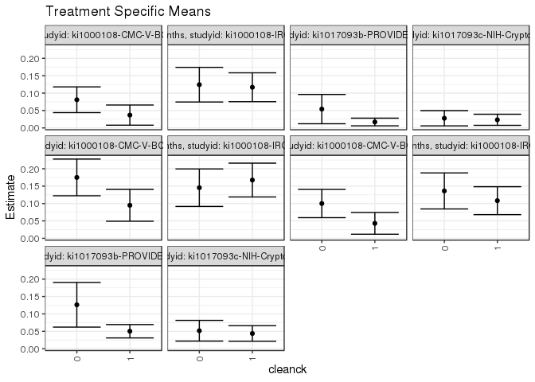

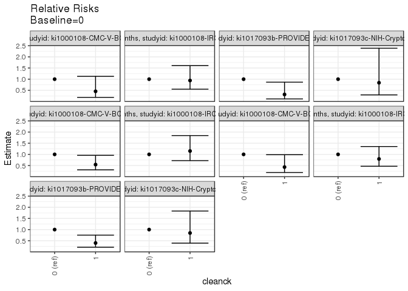

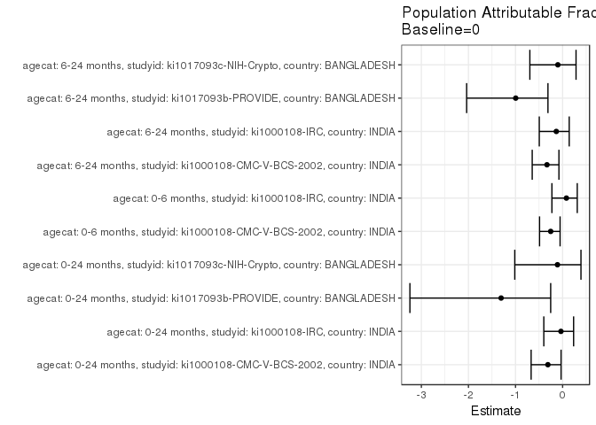

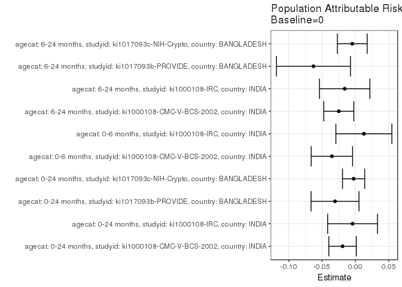

## Results Table

### Parameter: TSM

| agecat | studyid | country | intervention_level | baseline_level | estimate | ci_lower | ci_upper |
| --- | --- | --- | --- | --- | --- | --- | --- |
| 0-24 months | ki1000108-CMC-V-BCS-2002 | INDIA | 0 | NA | 0.0809524 | 0.0440117 | 0.1178931 |
| 0-24 months | ki1000108-CMC-V-BCS-2002 | INDIA | 1 | NA | 0.0368098 | 0.0078647 | 0.0657549 |
| 0-24 months | ki1000108-IRC | INDIA | 0 | NA | 0.1242604 | 0.0744635 | 0.1740572 |
| 0-24 months | ki1000108-IRC | INDIA | 1 | NA | 0.1168831 | 0.0754001 | 0.1583662 |
| 0-24 months | ki1017093b-PROVIDE | BANGLADESH | 0 | NA | 0.0540541 | 0.0119549 | 0.0961532 |
| 0-24 months | ki1017093b-PROVIDE | BANGLADESH | 1 | NA | 0.0170132 | 0.0059845 | 0.0280420 |
| 0-24 months | ki1017093c-NIH-Crypto | BANGLADESH | 0 | NA | 0.0277778 | 0.0058426 | 0.0497130 |
| 0-24 months | ki1017093c-NIH-Crypto | BANGLADESH | 1 | NA | 0.0233236 | 0.0073368 | 0.0393105 |
| 0-6 months | ki1000108-CMC-V-BCS-2002 | INDIA | 0 | NA | 0.1750000 | 0.1222665 | 0.2277335 |
| 0-6 months | ki1000108-CMC-V-BCS-2002 | INDIA | 1 | NA | 0.0949367 | 0.0491664 | 0.1407070 |
| 0-6 months | ki1000108-IRC | INDIA | 0 | NA | 0.1454545 | 0.0915914 | 0.1993177 |
| 0-6 months | ki1000108-IRC | INDIA | 1 | NA | 0.1674009 | 0.1187729 | 0.2160289 |
| 6-24 months | ki1000108-CMC-V-BCS-2002 | INDIA | 0 | NA | 0.1000000 | 0.0593704 | 0.1406296 |
| 6-24 months | ki1000108-CMC-V-BCS-2002 | INDIA | 1 | NA | 0.0429448 | 0.0117802 | 0.0741093 |
| 6-24 months | ki1000108-IRC | INDIA | 0 | NA | 0.1360947 | 0.0843338 | 0.1878556 |
| 6-24 months | ki1000108-IRC | INDIA | 1 | NA | 0.1082251 | 0.0681128 | 0.1483374 |
| 6-24 months | ki1017093b-PROVIDE | BANGLADESH | 0 | NA | 0.1262136 | 0.0620266 | 0.1904006 |
| 6-24 months | ki1017093b-PROVIDE | BANGLADESH | 1 | NA | 0.0502008 | 0.0310068 | 0.0693948 |
| 6-24 months | ki1017093c-NIH-Crypto | BANGLADESH | 0 | NA | 0.0516432 | 0.0218951 | 0.0813912 |
| 6-24 months | ki1017093c-NIH-Crypto | BANGLADESH | 1 | NA | 0.0437500 | 0.0213186 | 0.0661814 |

### Parameter: E(Y)

| agecat | studyid | country | intervention_level | baseline_level | estimate | ci_lower | ci_upper |
| --- | --- | --- | --- | --- | --- | --- | --- |
| 0-24 months | ki1000108-CMC-V-BCS-2002 | INDIA | NA | NA | 0.0616622 | 0.0372186 | 0.0861058 |
| 0-24 months | ki1000108-IRC | INDIA | NA | NA | 0.1200000 | 0.0881145 | 0.1518855 |
| 0-24 months | ki1017093b-PROVIDE | BANGLADESH | NA | NA | 0.0234375 | 0.0117074 | 0.0351676 |
| 0-24 months | ki1017093c-NIH-Crypto | BANGLADESH | NA | NA | 0.0250447 | 0.0120795 | 0.0380100 |
| 0-6 months | ki1000108-CMC-V-BCS-2002 | INDIA | NA | NA | 0.1396648 | 0.1037072 | 0.1756225 |
| 0-6 months | ki1000108-IRC | INDIA | NA | NA | 0.1581633 | 0.1219951 | 0.1943314 |
| 6-24 months | ki1000108-CMC-V-BCS-2002 | INDIA | NA | NA | 0.0750670 | 0.0482904 | 0.1018437 |
| 6-24 months | ki1000108-IRC | INDIA | NA | NA | 0.1200000 | 0.0881145 | 0.1518855 |
| 6-24 months | ki1017093b-PROVIDE | BANGLADESH | NA | NA | 0.0632280 | 0.0437545 | 0.0827015 |
| 6-24 months | ki1017093c-NIH-Crypto | BANGLADESH | NA | NA | 0.0469043 | 0.0289377 | 0.0648710 |

### Parameter: RR

| agecat | studyid | country | intervention_level | baseline_level | estimate | ci_lower | ci_upper |
| --- | --- | --- | --- | --- | --- | --- | --- |
| 0-24 months | ki1000108-CMC-V-BCS-2002 | INDIA | 0 | 0 | 1.0000000 | 1.0000000 | 1.0000000 |
| 0-24 months | ki1000108-CMC-V-BCS-2002 | INDIA | 1 | 0 | 0.4547095 | 0.1831858 | 1.1286937 |
| 0-24 months | ki1000108-IRC | INDIA | 0 | 0 | 1.0000000 | 1.0000000 | 1.0000000 |
| 0-24 months | ki1000108-IRC | INDIA | 1 | 0 | 0.9406308 | 0.5507267 | 1.6065797 |
| 0-24 months | ki1017093b-PROVIDE | BANGLADESH | 0 | 0 | 1.0000000 | 1.0000000 | 1.0000000 |
| 0-24 months | ki1017093b-PROVIDE | BANGLADESH | 1 | 0 | 0.3147448 | 0.1142567 | 0.8670329 |
| 0-24 months | ki1017093c-NIH-Crypto | BANGLADESH | 0 | 0 | 1.0000000 | 1.0000000 | 1.0000000 |
| 0-24 months | ki1017093c-NIH-Crypto | BANGLADESH | 1 | 0 | 0.8396501 | 0.2951043 | 2.3890277 |
| 0-6 months | ki1000108-CMC-V-BCS-2002 | INDIA | 0 | 0 | 1.0000000 | 1.0000000 | 1.0000000 |
| 0-6 months | ki1000108-CMC-V-BCS-2002 | INDIA | 1 | 0 | 0.5424955 | 0.3072438 | 0.9578757 |
| 0-6 months | ki1000108-IRC | INDIA | 0 | 0 | 1.0000000 | 1.0000000 | 1.0000000 |
| 0-6 months | ki1000108-IRC | INDIA | 1 | 0 | 1.1508811 | 0.7188350 | 1.8426026 |
| 6-24 months | ki1000108-CMC-V-BCS-2002 | INDIA | 0 | 0 | 1.0000000 | 1.0000000 | 1.0000000 |
| 6-24 months | ki1000108-CMC-V-BCS-2002 | INDIA | 1 | 0 | 0.4294479 | 0.1869451 | 0.9865223 |
| 6-24 months | ki1000108-IRC | INDIA | 0 | 0 | 1.0000000 | 1.0000000 | 1.0000000 |
| 6-24 months | ki1000108-IRC | INDIA | 1 | 0 | 0.7952193 | 0.4675748 | 1.3524545 |
| 6-24 months | ki1017093b-PROVIDE | BANGLADESH | 0 | 0 | 1.0000000 | 1.0000000 | 1.0000000 |
| 6-24 months | ki1017093b-PROVIDE | BANGLADESH | 1 | 0 | 0.3977448 | 0.2105149 | 0.7514952 |
| 6-24 months | ki1017093c-NIH-Crypto | BANGLADESH | 0 | 0 | 1.0000000 | 1.0000000 | 1.0000000 |
| 6-24 months | ki1017093c-NIH-Crypto | BANGLADESH | 1 | 0 | 0.8471591 | 0.3917905 | 1.8317915 |

### Parameter: PAR

| agecat | studyid | country | intervention_level | baseline_level | estimate | ci_lower | ci_upper |
| --- | --- | --- | --- | --- | --- | --- | --- |
| 0-24 months | ki1000108-CMC-V-BCS-2002 | INDIA | 0 | NA | -0.0192902 | -0.0399189 | 0.0013385 |
| 0-24 months | ki1000108-IRC | INDIA | 0 | NA | -0.0042604 | -0.0416909 | 0.0331702 |
| 0-24 months | ki1017093b-PROVIDE | BANGLADESH | 0 | NA | -0.0306166 | -0.0666048 | 0.0053717 |
| 0-24 months | ki1017093c-NIH-Crypto | BANGLADESH | 0 | NA | -0.0027331 | -0.0193887 | 0.0139226 |
| 0-6 months | ki1000108-CMC-V-BCS-2002 | INDIA | 0 | NA | -0.0353352 | -0.0664272 | -0.0042432 |
| 0-6 months | ki1000108-IRC | INDIA | 0 | NA | 0.0127087 | -0.0293271 | 0.0547445 |
| 6-24 months | ki1000108-CMC-V-BCS-2002 | INDIA | 0 | NA | -0.0249330 | -0.0474937 | -0.0023723 |
| 6-24 months | ki1000108-IRC | INDIA | 0 | NA | -0.0160947 | -0.0539359 | 0.0217466 |
| 6-24 months | ki1017093b-PROVIDE | BANGLADESH | 0 | NA | -0.0629856 | -0.1185465 | -0.0074247 |
| 6-24 months | ki1017093c-NIH-Crypto | BANGLADESH | 0 | NA | -0.0047389 | -0.0271097 | 0.0176319 |

### Parameter: PAF

| agecat | studyid | country | intervention_level | baseline_level | estimate | ci_lower | ci_upper |
| --- | --- | --- | --- | --- | --- | --- | --- |
| 0-24 months | ki1000108-CMC-V-BCS-2002 | INDIA | 0 | NA | -0.3128364 | -0.6687765 | -0.0328162 |
| 0-24 months | ki1000108-IRC | INDIA | 0 | NA | -0.0355030 | -0.3993601 | 0.2337452 |
| 0-24 months | ki1017093b-PROVIDE | BANGLADESH | 0 | NA | -1.3063062 | -3.2435650 | -0.2534387 |
| 0-24 months | ki1017093c-NIH-Crypto | BANGLADESH | 0 | NA | -0.1091270 | -1.0160383 | 0.3898119 |
| 0-6 months | ki1000108-CMC-V-BCS-2002 | INDIA | 0 | NA | -0.2530000 | -0.4897959 | -0.0538417 |
| 0-6 months | ki1000108-IRC | INDIA | 0 | NA | 0.0803519 | -0.2272543 | 0.3108579 |
| 6-24 months | ki1000108-CMC-V-BCS-2002 | INDIA | 0 | NA | -0.3321428 | -0.6457730 | -0.0782803 |
| 6-24 months | ki1000108-IRC | INDIA | 0 | NA | -0.1341223 | -0.4958296 | 0.1401204 |
| 6-24 months | ki1017093b-PROVIDE | BANGLADESH | 0 | NA | -0.9961676 | -2.0385611 | -0.3113724 |
| 6-24 months | ki1017093c-NIH-Crypto | BANGLADESH | 0 | NA | -0.1010328 | -0.6958020 | 0.2851327 |